# Lab 3 — Redes sociales y adopción de tecnología en Malawi

A quién le cuentan primero (réplica de Beaman et al., 2021)

Autor/a

Economía del Desarrollo (06230) · Universidad ICESI

Fecha de publicación

7 de septiembre de 2026

## 1 De qué se trata

La **siembra en hoyos** (*pit planting*) es una técnica barata de conservación de suelo y agua: en vez de arar el campo entero, se abren hoyos donde va la semilla. No cuesta insumos, aumenta el rendimiento en terrenos secos y en Malawi el servicio de extensión agrícola lleva años tratando de difundirla. Casi nadie la usa.

En **200 aldeas** de tres distritos semiáridos, un programa capacitó a **dos agricultores** por aldea para que la enseñaran a sus vecinos. Lo que se aleatorizó no fue el programa —todas las aldeas lo recibieron— sino **la regla para elegir a esos dos**:

1. **Benchmark** — los elige el extensionista, como se ha hecho siempre.
2. **Geo** — los elige un algoritmo que solo sabe quién vive cerca de quién.
3. **Contagio simple** — un algoritmo de teoría de redes que supone que a la gente le basta **un** vecino adoptante para convencerse.
4. **Contagio complejo** — el mismo algoritmo, pero suponiendo que hacen falta **dos**.

La pregunta de Beaman, BenYishay, Magruder y Mobarak es de una economía brutal:

> **Con el mismo programa y el mismo presupuesto, ¿cambia algo elegir distinto a quién le cuentan primero?**

**AdvertenciaEl supuesto acá viene con el diseño — pero no sale gratis**

A diferencia del Lab 2, no vamos a defender ninguna continuidad. Los cuatro grupos son comparables **porque hubo un sorteo**, y un sorteo no deja nada por fuera: ni lo que observamos ni lo que no. Ese es el lujo de un experimento.

Lo que el sorteo **no** compra: el año 3 pierde un distrito entero (200 → 141 aldeas), un agricultor de una aldea tratada le puede contar a un primo de una aldea de comparación (**derrames**), cuatro brazos × dos resultados × dos años son **muchas pruebas a la vez**, y todo esto ocurre con una tecnología concreta en tres distritos concretos. Un RCT resuelve el problema de la selección, no todos los problemas.

## 2 Preparación

`pacman` instala lo que falte y carga lo que ya esté: una sola línea para todo.

```r
if (!require("pacman")) install.packages("pacman")
pacman::p_load(tidyverse, scales, fixest, broom)

aldeas <- read_rds("datos/beaman_redes_aldeas.rds") |>
  as_tibble()

socios <- read_rds("datos/beaman_redes_socios.rds") |>
  as_tibble()

# Para el balance fino (Tabla A5) y el mecanismo (Tabla 3).
censo <- read_rds("datos/beaman_redes_censo.rds") |>
  as_tibble()

conversaciones <- read_rds("datos/beaman_redes_conversaciones.rds") |>
  as_tibble()

# El azul del control y el naranja del tratamiento son los mismos del Lab 2.
colores_brazo <- c("Benchmark" = "#2c7fb8", "Geo"      = "#a6bddb",
                   "Simple"    = "#fdae61", "Complejo" = "#d95f0e")
```

Cuatro archivos: **aldeas** (las 200 del experimento, que es la unidad de la Tabla 2 del paper), **socios** (los agricultores que cada algoritmo elegiría), **censo** (los 14.909 agricultores de línea base, para el balance fino) y **conversaciones** (43.525 pares respondente-socio, para rastrear el mecanismo).

## 3 Una mirada a los datos

```r
dim(aldeas)
```

```
[1] 200  19
```

```r
aldeas |>
  count(brazo)
```

| brazo | n |
| --- | --- |
| Benchmark | 50 |
| Geo | 50 |
| Simple | 50 |
| Complejo | 50 |

**Benchmark es la categoría omitida.** Los tres coeficientes que vamos a estimar se leen todos contra ella: contra lo que pasa cuando elige el extensionista.

El sorteo se hizo **por separado dentro de cada distrito**. Por eso el distrito va a entrar después como efecto fijo: no es un control cosmético que uno agrega por si acaso, es parte del diseño experimental.

```r
aldeas |>
  count(distrito, brazo) |>
  pivot_wider(names_from = brazo, values_from = n)
```

| distrito | Benchmark | Geo | Simple | Complejo |
| --- | --- | --- | --- | --- |
| 1 | 7 | 7 | 8 | 8 |
| 2 | 28 | 28 | 27 | 28 |
| 3 | 15 | 15 | 15 | 14 |

El resultado principal es `adopcion_alguna_a2`: **1 si al menos un agricultor no-semilla** adoptó la siembra en hoyos en el año 2. Ojo con esa exclusión —los dos capacitados no cuentan—: si contaran, todas las aldeas darían 1 por construcción y no habría nada que medir.

```r
aldeas |>
  group_by(distrito) |>
  summarise(aldeas = n(), en_el_ano_3 = sum(en_a3))
```

| distrito | aldeas | en_el_ano_3 |
| --- | --- | --- |
| 1 | 30 | 30 |
| 2 | 111 | 111 |
| 3 | 59 | 0 |

Guarde ese cuadro. El año 3 no es una muestra más pequeña al azar: es la misma muestra **menos un distrito completo**. Volvemos sobre eso en Sección 8.

## 4 Cuatro formas de elegir a quién capacitar

> **Antes de mirar resultados, pregúntese si el tratamiento mordió.** Si los cuatro algoritmos hubieran terminado eligiendo gente parecida, no habría experimento que valga: estaríamos comparando cuatro versiones de lo mismo.

Un **socio** es quien un algoritmo elegiría como punto de entrada de la información. Si a su aldea le tocó ese brazo, lo capacitaron —es una **semilla**—; si no, quedó como contrafactual observable, una **sombra**.

Fíjese en la unidad, porque es lo que hace limpia la comparación: la columna `tipo` **no es el brazo que recibió la aldea**, es el algoritmo que elegiría a *ese* agricultor. Como los cuatro algoritmos se pueden correr sobre las 200 aldeas —hayan recibido ese brazo o no—, comparamos a los elegidos de cada uno en toda la muestra.

Hay dos maneras de medir qué tan conectado está alguien. El **grado** es con cuánta gente habla. La **centralidad de vector propio** es más sutil: mide qué tan conectada es la gente con la que habla. Y cada una trae su propio rango, porque el socio más central por vector propio no siempre es el de más contactos.

```r
tabla_centralidad <- bind_rows(
  socios |>
    filter(rango_ev <= 2) |>
    summarise(valor = mean(centralidad_ev, na.rm = TRUE), n = n(),
              .by = c(tipo, rango_ev)) |>
    rename(rango = rango_ev) |>
    mutate(medida = "Centralidad de vector propio"),
  socios |>
    filter(rango_grado <= 2) |>
    summarise(valor = mean(grado, na.rm = TRUE), n = n(),
              .by = c(tipo, rango_grado)) |>
    rename(rango = rango_grado) |>
    mutate(medida = "Grado (número de contactos)")
)

# Reordenada para que se lea igual que la Tabla 1 del paper.
tabla_centralidad |>
  select(medida, tipo, rango, valor) |>
  pivot_wider(names_from = rango, values_from = valor, names_prefix = "socio_") |>
  arrange(medida, tipo)
```

| medida | tipo | socio_1 | socio_2 |
| --- | --- | --- | --- |
| Centralidad de vector propio | Benchmark | 0.2080565 | 0.1264924 |
| Centralidad de vector propio | Geo | 0.1494937 | 0.0977988 |
| Centralidad de vector propio | Simple | 0.2690148 | 0.0742289 |
| Centralidad de vector propio | Complejo | 0.2794331 | 0.1923862 |
| Grado (número de contactos) | Benchmark | 13.2857143 | 9.8000000 |
| Grado (número de contactos) | Geo | 9.4761905 | 6.3402778 |
| Grado (número de contactos) | Simple | 16.5917431 | 6.6951220 |
| Grado (número de contactos) | Complejo | 17.4906542 | 13.3922652 |

**ImportanteUna trampa de réplica que casi no se ve**

Para armar esta tabla hay que ordenar a los socios de cada aldea por centralidad. El do-file original usa `egen rank(), track` de Stata, que a los **empatados les da a todos el rango menor y salta el siguiente**: 1, 1, 3. El equivalente en R es `rank(..., ties.method = "min")`, y así se construyeron `rango_ev` y `rango_grado` en `R/00-construir-datos.R`.

Si uno usa `ties.method = "first"` —el reflejo natural, porque parece dar igual— el grado del brazo complejo pasa de **17,49** a **18,08**. No falla nada. No hay advertencia. La tabla simplemente deja de ser la del paper.

Ese es el trabajo real de una réplica: no correr la regresión, sino descubrir las decisiones que el autor tomó y no escribió en el texto.

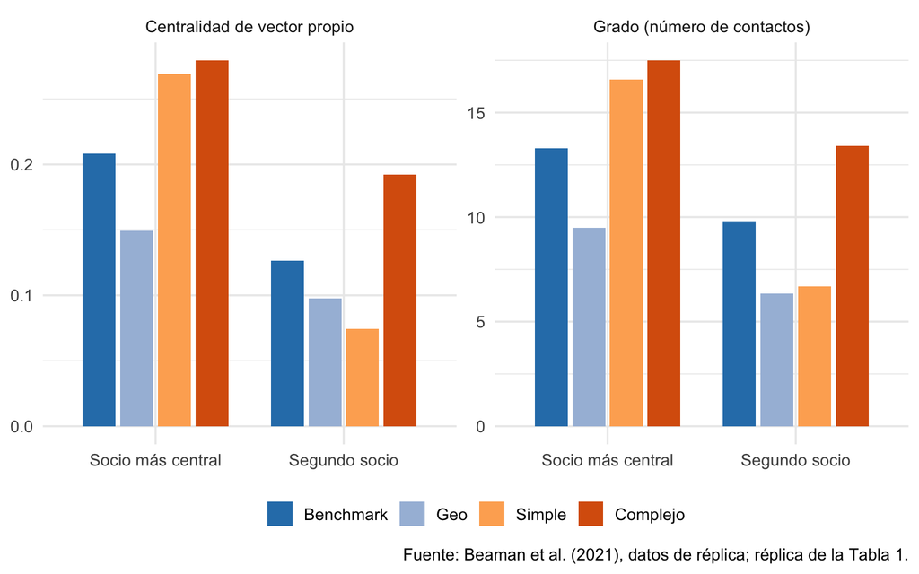

Figura 1: Promedio de los dos socios que elegiría cada algoritmo, en las 200 aldeas.

```r
ggplot(tabla_centralidad, aes(factor(rango), valor, fill = tipo)) +
  geom_col(position = position_dodge(width = 0.8), width = 0.7) +
  facet_wrap(~ medida, scales = "free_y") +
  scale_fill_manual(values = colores_brazo) +
  scale_x_discrete(labels = c("1" = "Socio más central", "2" = "Segundo socio")) +
  labs(x = NULL, y = NULL, fill = NULL,
       caption = "Fuente: Beaman et al. (2021), datos de réplica; réplica de la Tabla 1.") +
  theme_minimal(base_size = 13) +
  theme(legend.position = "bottom")
```

La diferencia entre los algoritmos **no está en el primer socio, está en el segundo**. El contagio simple supone que basta un contacto adoptante para convencerse, así que gasta su segundo cupo en la periferia de la red. El contagio complejo supone que hacen falta dos vecinos adoptando, así que pone a los **dos** socios en el centro y con contactos en común. Geo, que solo sabe de distancias, no acierta ni con el primero.

## 5 ¿Funcionó la aleatorización?

Acá está la diferencia de fondo con el Lab 2. Allá el supuesto de continuidad no se podía probar, solo atacar. Acá el supuesto **lo garantiza el sorteo**. Pero un sorteo puede salir torcido por azar, así que igual se verifica: regresamos cada característica de **línea base** sobre los brazos y pedimos que no pase nada.

Es la misma receta del Lab 2 —cambiar lo que va a la izquierda del `~`— envuelta en una función para no repetirla cuatro veces.

```r
covariables_base <- c("compost_base", "fertilizante_base", "hoyos_base", "tam_aldea")

balancear <- function(variable) {
  m <- feols(as.formula(paste(variable, "~ complex + simple + geo | distrito")),
             data = aldeas, cluster = ~aldea, notes = FALSE)
  conjunta <- wald(m, "complex|simple|geo", print = FALSE)
  tidy(m) |>
    filter(term %in% c("complex", "simple", "geo")) |>
    transmute(variable, brazo = term, coef = estimate, ee = std.error,
              p = p.value, p_conjunta = conjunta$p)
}

balance <- map_dfr(covariables_base, balancear)
balance
```

| variable | brazo | coef | ee | p | p_conjunta |
| --- | --- | --- | --- | --- | --- |
| compost_base | complex | 0.0016695 | 0.0335711 | 0.9603863 | 0.8660330 |
| compost_base | simple | -0.0216190 | 0.0359843 | 0.5486642 | 0.8660330 |
| compost_base | geo | -0.0188814 | 0.0364544 | 0.6050709 | 0.8660330 |
| fertilizante_base | complex | -0.0032396 | 0.0293216 | 0.9121374 | 0.9953675 |
| fertilizante_base | simple | 0.0039360 | 0.0321033 | 0.9025446 | 0.9953675 |
| fertilizante_base | geo | 0.0023994 | 0.0327287 | 0.9416318 | 0.9953675 |
| hoyos_base | complex | -0.0082079 | 0.0130416 | 0.5298335 | 0.9181504 |
| hoyos_base | simple | -0.0064048 | 0.0132165 | 0.6284895 | 0.9181504 |
| hoyos_base | geo | -0.0009953 | 0.0167657 | 0.9527199 | 0.9181504 |
| tam_aldea | complex | -3.9030988 | 10.1227595 | 0.7002222 | 0.5278694 |
| tam_aldea | simple | 10.5600597 | 10.6036791 | 0.3205148 | 0.5278694 |
| tam_aldea | geo | 2.8000000 | 10.4589211 | 0.7891967 | 0.5278694 |

### 5.1 El balance fino: doce variables a nivel de agricultor

Las cuatro variables de arriba son de aldea. El paper hace su balance con **doce** del censo de redes, a nivel de agricultor (su Tabla A5), y ahí es donde aparece lo interesante. Ahora sí lo podemos correr nosotros.

```r
variables_censo <- c("vivienda_pc", "activos_pc", "ganado_pc", "fert_basal",
                     "fert_cobertura", "adultos", "ninos", "tam_finca",
                     "tierra_propia", "rendimiento", "presta_ganyu", "usa_ganyu")

balance_censo <- map_dfr(variables_censo, function(v) {
  m <- feols(as.formula(paste(v, "~ complex + simple + geo +",
                              "hoyos_base + fertilizante_base + compost_base | distrito")),
             data = censo, cluster = ~aldea, notes = FALSE)
  tibble(variable = v,
         p_conjunta = wald(m, "complex|simple|geo", print = FALSE)$p,
         n = nobs(m))
}) |>
  arrange(p_conjunta)

balance_censo
```

| variable | p_conjunta | n |
| --- | --- | --- |
| vivienda_pc | 0.0572332 | 14027 |
| tam_finca | 0.0713352 | 14021 |
| usa_ganyu | 0.1243226 | 14016 |
| ganado_pc | 0.2232338 | 14284 |
| presta_ganyu | 0.6353903 | 14016 |
| ninos | 0.7506085 | 14284 |
| fert_cobertura | 0.7789469 | 10475 |
| rendimiento | 0.8519769 | 13438 |
| activos_pc | 0.8797799 | 14284 |
| tierra_propia | 0.9317618 | 14284 |
| fert_basal | 0.9706052 | 10374 |
| adultos | 0.9749884 | 14041 |

Dos de las doce quedan por debajo de 0,10: el índice de **vivienda** (0,057) y el **tamaño de finca** (0,071). Y acá viene lo que de verdad hay que aprender de esta tabla.

**ImportanteCómo se lee un balance con dos banderas rojas**

Con doce pruebas al 10 %, lo **esperado por puro azar** es que 1,2 salgan «significativas». Salieron dos. Eso no rompe el experimento: es exactamente lo que produce un sorteo honesto.

Lo que sí hay que hacer es **decirlo**. Los autores reportan las doce, señalan que el tamaño de finca es el caso más incómodo y muestran que controlar por él no cambia ningún resultado. Un balance donde *nada* saliera desbalanceado sería más sospechoso que este.

La pregunta correcta ante una bandera roja nunca es «¿se invalida el estudio?», sino **«¿esta diferencia podría producir el resultado que estamos viendo?»**. Fincas algo más grandes en el brazo Benchmark irían *en contra* del hallazgo, no a favor.

Dividimos `coef / ee` para obtener el **estadístico t**: así variables medidas en unidades distintas quedan comparables en el mismo eje.

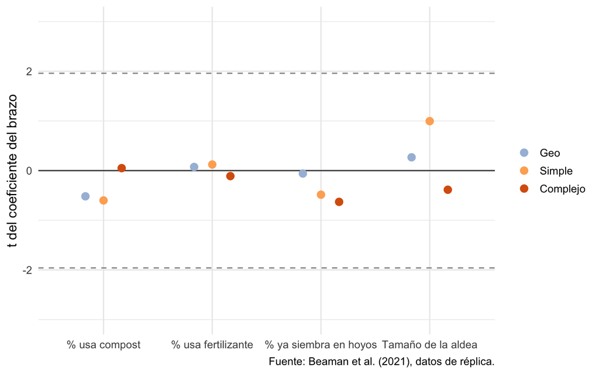

Figura 2: Diferencia contra Benchmark en las variables de línea base, en unidades de error estándar.

```r
etiquetas_base <- c(compost_base      = "% usa compost",
                    fertilizante_base = "% usa fertilizante",
                    hoyos_base        = "% ya siembra en hoyos",
                    tam_aldea         = "Tamaño de la aldea")

balance |>
  mutate(etiqueta = factor(etiquetas_base[variable], levels = etiquetas_base),
         brazo    = factor(str_to_title(brazo),
                           levels = c("Geo", "Simple", "Complex"),
                           labels = c("Geo", "Simple", "Complejo")),
         t = coef / ee) |>
  ggplot(aes(etiqueta, t, color = brazo)) +
  geom_hline(yintercept = c(-1.96, 1.96), linetype = "dashed", color = "grey60") +
  geom_hline(yintercept = 0, color = "grey30") +
  geom_point(size = 3, position = position_dodge(width = 0.5)) +
  scale_color_manual(values = colores_brazo) +
  coord_cartesian(ylim = c(-3, 3)) +
  labs(x = NULL, y = "t del coeficiente del brazo", color = NULL,
       caption = "Fuente: Beaman et al. (2021), datos de réplica.") +
  theme_minimal(base_size = 13)
```

## 6 La diferencia de medias

> **El estimador más honesto de un experimento es una resta.** Si la aleatorización funcionó, comparar promedios crudos ya es insesgado. Todo lo que viene después sirve para ganar precisión, no para arreglar un sesgo.

```r
medias_brazo <- aldeas |>
  group_by(brazo) |>
  summarise(aldeas   = n(),
            adopcion = mean(adopcion_alguna_a2),
            ee       = sd(adopcion_alguna_a2) / sqrt(n()),
            .groups  = "drop")

medias_brazo
```

| brazo | aldeas | adopcion | ee |
| --- | --- | --- | --- |
| Benchmark | 50 | 0.42 | 0.0705084 |
| Geo | 50 | 0.52 | 0.0713714 |
| Simple | 50 | 0.56 | 0.0709124 |
| Complejo | 50 | 0.68 | 0.0666395 |

Mire el número de Benchmark antes de seguir. En **3 de cada 5 aldeas** del grupo de comparación, **dos años después** de haber capacitado a dos vecinos, no había adoptado **nadie más**. La difusión no es lenta: sencillamente no arranca.

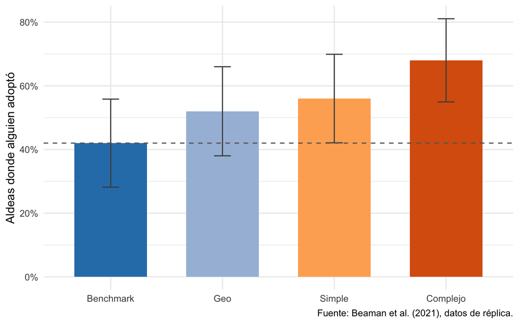

Figura 3: Aldeas con al menos un adoptante no-semilla en el año 2, por brazo. La línea punteada es el nivel Benchmark.

```r
ggplot(medias_brazo, aes(brazo, adopcion, fill = brazo)) +
  geom_col(width = 0.65) +
  geom_errorbar(aes(ymin = adopcion - 1.96 * ee, ymax = adopcion + 1.96 * ee),
                width = 0.15, color = "grey30") +
  geom_hline(yintercept = medias_brazo$adopcion[medias_brazo$brazo == "Benchmark"],
             linetype = "dashed", color = "grey40") +
  scale_fill_manual(values = colores_brazo, guide = "none") +
  scale_y_continuous(labels = label_percent()) +
  labs(x = NULL, y = "Aldeas donde alguien adoptó",
       caption = "Fuente: Beaman et al. (2021), datos de réplica.") +
  theme_minimal(base_size = 13)
```

La resta cruda contra Benchmark, sin ningún control de por medio:

```r
medias_brazo |>
  mutate(diferencia = adopcion - adopcion[brazo == "Benchmark"]) |>
  select(brazo, aldeas, adopcion, diferencia)
```

| brazo | aldeas | adopcion | diferencia |
| --- | --- | --- | --- |
| Benchmark | 50 | 0.42 | 0.00 |
| Geo | 50 | 0.52 | 0.10 |
| Simple | 50 | 0.56 | 0.14 |
| Complejo | 50 | 0.68 | 0.26 |

## 7 La regresión

La regresión hace lo mismo que la resta, con dos añadidos: absorbe los **efectos fijos de distrito** —los estratos del sorteo— y ajusta por los tres controles que entraron en la rutina de re-aleatorización, más el tamaño de la aldea y su cuadrado.

**ImportanteQué está haciendo de verdad `cluster = ~aldea`**

Los errores estándar se agrupan por aldea, tal como lo declara el paper. Pero acá hay **una sola fila por aldea**: agrupar por aldea es lo mismo que pedir errores robustos a heterocedasticidad, porque no hay nada que agrupar.

No está mal —el resultado es el correcto— pero conviene saber qué hace la línea que uno escribe. El agrupamiento importa cuando varias observaciones comparten el tratamiento; si el dato ya viene colapsado al nivel del tratamiento, el trabajo ya está hecho.

```r
m_a2_alguna <- feols(
  adopcion_alguna_a2 ~ complex + simple + geo +
    compost_base + fertilizante_base + hoyos_base + tam_aldea + I(tam_aldea^2) | distrito,
  data = aldeas, cluster = ~aldea
)

# tidy() saca la tabla de coeficientes como un tibble; nos quedamos con los brazos.
tidy(m_a2_alguna) |>
  filter(term %in% c("complex", "simple", "geo"))
```

| term | estimate | std.error | statistic | p.value |
| --- | --- | --- | --- | --- |
| complex | 0.2523218 | 0.0927968 | 2.719080 | 0.0071249 |
| simple | 0.1546996 | 0.1003587 | 1.541466 | 0.1247921 |
| geo | 0.1066423 | 0.0963869 | 1.106398 | 0.2698902 |

Como el resultado es una variable 0/1, el coeficiente se lee directo en **puntos porcentuales**:

```r
efecto_principal <- tidy(m_a2_alguna) |>
  filter(term == "complex") |>
  mutate(media_benchmark = mean(aldeas$adopcion_alguna_a2[aldeas$brazo == "Benchmark"]),
         efecto_pp       = estimate * 100,
         aldeas          = nobs(m_a2_alguna)) |>
  select(coeficiente = estimate, ee = std.error, p = p.value,
         media_benchmark, efecto_pp, aldeas)

efecto_principal
```

| coeficiente | ee | p | media_benchmark | efecto_pp | aldeas |
| --- | --- | --- | --- | --- | --- |
| 0.2523218 | 0.0927968 | 0.0071249 | 0.42 | 25.23218 | 200 |

**Elegir a los dos capacitados con el algoritmo de contagio complejo sube unos 25 puntos porcentuales la probabilidad de que la difusión arranque**, sobre una base de 42 %. Es más de la mitad del nivel del grupo de comparación, y no costó un peso adicional: es el mismo programa, con otra lista de invitados.

### 7.1 Las otras tres columnas de la Tabla 2

Entre las cuatro columnas cambian solo dos cosas: el **resultado** (¿arrancó la difusión? frente a ¿qué tan rápido?) y el **año**. Las escribimos una por una para que se vea.

```r
m_a3_alguna <- feols(
  adopcion_alguna_a3 ~ complex + simple + geo +
    compost_base + fertilizante_base + hoyos_base + tam_aldea + I(tam_aldea^2) | distrito,
  data = aldeas, cluster = ~aldea
)

m_a2_tasa <- feols(
  tasa_adopcion_a2 ~ complex + simple + geo +
    compost_base + fertilizante_base + hoyos_base + tam_aldea + I(tam_aldea^2) | distrito,
  data = aldeas, cluster = ~aldea
)

m_a3_tasa <- feols(
  tasa_adopcion_a3 ~ complex + simple + geo +
    compost_base + fertilizante_base + hoyos_base + tam_aldea + I(tam_aldea^2) | distrito,
  data = aldeas, cluster = ~aldea
)
```

A cada `tidy()` le pegamos la etiqueta de qué columna es y apilamos con `bind_rows()`.

```r
tabla2 <- bind_rows(
  tidy(m_a2_alguna) |> mutate(columna = "(1) ¿Arrancó? — año 2", n = nobs(m_a2_alguna)),
  tidy(m_a3_alguna) |> mutate(columna = "(2) ¿Arrancó? — año 3", n = nobs(m_a3_alguna)),
  tidy(m_a2_tasa)   |> mutate(columna = "(3) Tasa — año 2",      n = nobs(m_a2_tasa)),
  tidy(m_a3_tasa)   |> mutate(columna = "(4) Tasa — año 3",      n = nobs(m_a3_tasa))
) |>
  filter(term %in% c("complex", "simple", "geo")) |>
  select(columna, brazo = term, coef = estimate, ee = std.error, p = p.value, n) |>
  mutate(coef = round(coef, 3), ee = round(ee, 3), p = round(p, 3))

tabla2
```

| columna | brazo | coef | ee | p | n |
| --- | --- | --- | --- | --- | --- |
| (1) ¿Arrancó? — año 2 | complex | 0.252 | 0.093 | 0.007 | 200 |
| (1) ¿Arrancó? — año 2 | simple | 0.155 | 0.100 | 0.125 | 200 |
| (1) ¿Arrancó? — año 2 | geo | 0.107 | 0.096 | 0.270 | 200 |
| (2) ¿Arrancó? — año 3 | complex | 0.304 | 0.101 | 0.003 | 141 |
| (2) ¿Arrancó? — año 3 | simple | 0.189 | 0.111 | 0.092 | 141 |
| (2) ¿Arrancó? — año 3 | geo | 0.188 | 0.110 | 0.089 | 141 |
| (3) Tasa — año 2 | complex | 0.036 | 0.016 | 0.024 | 200 |
| (3) Tasa — año 2 | simple | 0.036 | 0.017 | 0.032 | 200 |
| (3) Tasa — año 2 | geo | 0.038 | 0.027 | 0.165 | 200 |
| (4) Tasa — año 3 | complex | 0.036 | 0.026 | 0.169 | 141 |
| (4) Tasa — año 3 | simple | 0.006 | 0.022 | 0.775 | 141 |
| (4) Tasa — año 3 | geo | 0.013 | 0.034 | 0.695 | 141 |

Las columnas de **tasa** cuentan una historia distinta y más sobria: la proporción de agricultores que adopta sube apenas unos 3,6 puntos sobre una base de 3,8 %. Es decir, el targeting logra que la difusión **empiece** en muchas más aldeas, pero donde empieza sigue siendo un fenómeno pequeño. Los autores lo argumentan así: con una adopción tan baja, lo que importa a tres años es si el proceso arranca, porque una aldea con cero adoptantes después de tres años probablemente no adopte nunca.

## 8 ¿Aguanta el resultado?

> **La lección incómoda del Lab 2, al revés.** Allá había que probar que el resultado no dependía de las decisiones del investigador. Acá el sorteo hace ese trabajo, y por eso la prueba de robustez cambia de forma: no preguntamos si el número se mueve, sino si **se mueve cuando no debería**.

### 8.1 Con controles y sin controles

En un experimento los controles **no deberían mover el punto**: si el sorteo funcionó, están incorrelacionados con el tratamiento y solo bajan el ruido. Que el coeficiente salte al agregarlos es señal de alarma, no de rigor.

```r
m_pelado <- feols(adopcion_alguna_a2 ~ complex + simple + geo,
                  data = aldeas, vcov = "hetero")

m_solo_ef <- feols(adopcion_alguna_a2 ~ complex + simple + geo | distrito,
                   data = aldeas, cluster = ~aldea)

bind_rows(
  tidy(m_pelado)    |> mutate(especificacion = "1. Solo los brazos"),
  tidy(m_solo_ef)   |> mutate(especificacion = "2. + efectos fijos de distrito"),
  tidy(m_a2_alguna) |> mutate(especificacion = "3. + controles (Tabla 2)")
) |>
  filter(term == "complex") |>
  select(especificacion, coef = estimate, ee = std.error, p = p.value)
```

| especificacion | coef | ee | p |
| --- | --- | --- | --- |
| 1. Solo los brazos | 0.2600000 | 0.0970167 | 0.0079898 |
| 2. + efectos fijos de distrito | 0.2515973 | 0.0930878 | 0.0074703 |
| 3. + controles (Tabla 2) | 0.2523218 | 0.0927968 | 0.0071249 |

### 8.2 Inferencia por aleatorización

El valor p de la regresión sale de una fórmula asintótica: supone que el estimador se distribuye normal en muestras grandes. Con 200 aldeas eso es discutible, y en un experimento hay algo mejor: **repetir el sorteo**.

Volvemos a repartir los brazos **dentro de cada distrito** —como se hizo de verdad—, estimamos otra vez y guardamos el coeficiente. Dos mil veces. Eso construye la distribución del efecto **si el tratamiento no hiciera nada**. Después miramos qué tan raro es el número que efectivamente observamos.

```r
set.seed(2026)

una_permutacion <- function() {
  permutada <- aldeas |>
    group_by(distrito) |>
    mutate(brazo_p = sample(brazo)) |>       # re-sorteo dentro del estrato
    ungroup() |>
    mutate(complex_p = as.integer(brazo_p == "Complejo"),
           simple_p  = as.integer(brazo_p == "Simple"),
           geo_p     = as.integer(brazo_p == "Geo"))

  coef(feols(
    adopcion_alguna_a2 ~ complex_p + simple_p + geo_p +
      compost_base + fertilizante_base + hoyos_base + tam_aldea + I(tam_aldea^2) | distrito,
    data = permutada, notes = FALSE
  ))[["complex_p"]]
}

nulos <- map_dbl(1:2000, \(i) una_permutacion())

coef_observado    <- coef(m_a2_alguna)[["complex"]]
p_aleatorizacion  <- mean(abs(nulos) >= abs(coef_observado))

tibble(
  coef_observado,
  p_regresion      = tidy(m_a2_alguna) |> filter(term == "complex") |> pull(p.value),
  p_aleatorizacion
)
```

| coef_observado | p_regresion | p_aleatorizacion |
| --- | --- | --- |
| 0.2523218 | 0.0071249 | 0.0095 |

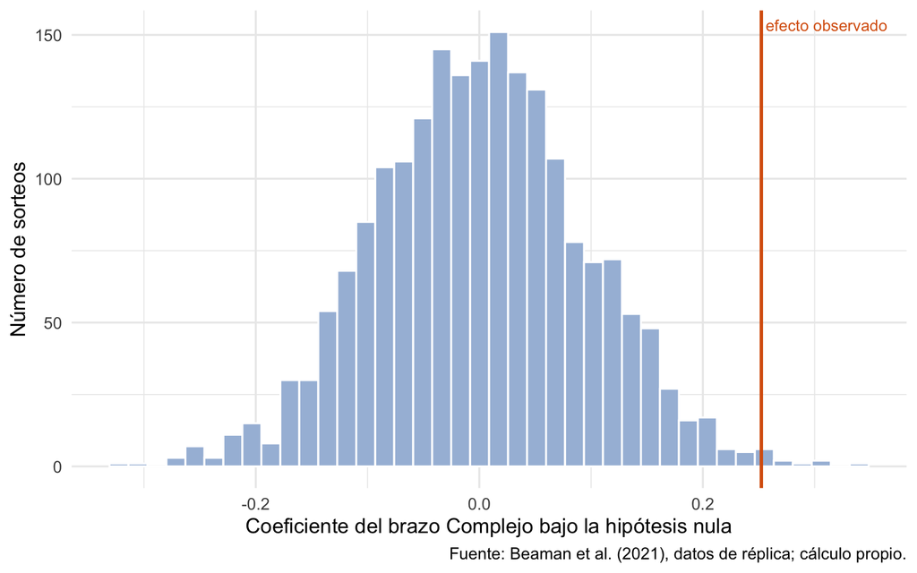

Figura 4: Distribución del coeficiente del brazo Complejo bajo 2.000 re-sorteos dentro de cada distrito.

```r
ggplot(tibble(nulos = nulos), aes(nulos)) +
  geom_histogram(bins = 40, fill = "#a6bddb", color = "white") +
  geom_vline(xintercept = coef_observado, color = "#d95f0e", linewidth = 1) +
  annotate("text", x = coef_observado, y = Inf, label = " efecto observado",
           hjust = 0, vjust = 1.8, size = 3.5, color = "#d95f0e") +
  labs(x = "Coeficiente del brazo Complejo bajo la hipótesis nula",
       y = "Número de sorteos",
       caption = "Fuente: Beaman et al. (2021), datos de réplica; cálculo propio.") +
  theme_minimal(base_size = 13)
```

Cuando los dos valores p coinciden, la aproximación normal estaba bien. Cuando difieren, **el de aleatorización es el que hay que creer**: no le pide normalidad a nada, solo reproduce el sorteo que de verdad ocurrió.

### 8.3 La atrición del año 3

```r
aldeas |>
  group_by(distrito) |>
  summarise(aldeas = n(), en_el_ano_3 = sum(en_a3))
```

| distrito | aldeas | en_el_ano_3 |
| --- | --- | --- |
| 1 | 30 | 30 |
| 2 | 111 | 111 |
| 3 | 59 | 0 |

El coeficiente del año 3 **no es comparable** con el del año 2: entre uno y otro no solo pasó un año, también cambió el país que estamos mirando. Para compararlos hay que correr el año 2 sobre las **mismas aldeas** del año 3.

```r
m_a2_muestra_a3 <- feols(
  adopcion_alguna_a2 ~ complex + simple + geo +
    compost_base + fertilizante_base + hoyos_base + tam_aldea + I(tam_aldea^2) | distrito,
  data = filter(aldeas, en_a3 == 1), cluster = ~aldea
)

bind_rows(
  tidy(m_a2_alguna)     |> mutate(muestra = "Año 2, las 200 aldeas",     n = nobs(m_a2_alguna)),
  tidy(m_a2_muestra_a3) |> mutate(muestra = "Año 2, solo las del año 3", n = nobs(m_a2_muestra_a3)),
  tidy(m_a3_alguna)     |> mutate(muestra = "Año 3, las mismas aldeas",  n = nobs(m_a3_alguna))
) |>
  filter(term == "complex") |>
  select(muestra, coef = estimate, ee = std.error, n)
```

| muestra | coef | ee | n |
| --- | --- | --- | --- |
| Año 2, las 200 aldeas | 0.2523218 | 0.0927968 | 200 |
| Año 2, solo las del año 3 | 0.3655995 | 0.1064631 | 141 |
| Año 3, las mismas aldeas | 0.3044410 | 0.1012005 | 141 |

## 9 ¿Por qué funcionó? El mecanismo

Hasta acá sabemos **que** el targeting funcionó. Falta el **por qué**, y son dos preguntas distintas: ¿el canal fue hablar? y ¿por qué haría falta targetear, para empezar?

### 9.1 ¿De verdad hablaron?

A cada vecino se le preguntó por unos socios concretos: unos capacitados y otros sombra. Acá está lo elegante del diseño: como **solo** se pregunta por socios —la gente que algún algoritmo habría elegido— cuál de ellos resultó capacitado es **aleatorio**. Es un segundo experimento adentro del primero, y sale gratis.

```r
tabla3 <- map_dfr(1:3, function(y) {
  muestra <- filter(conversaciones, anio == y)
  m <- feols(hablaron ~ capacitado + socio_simple + socio_complejo + socio_geo +
               compost_base + fertilizante_base + hoyos_base + tam_aldea + I(tam_aldea^2) | distrito,
             data = muestra, cluster = ~aldea, notes = FALSE)
  tibble(anio = y,
         efecto_capacitado = coef(m)[["capacitado"]],
         ee                = se(m)[["capacitado"]],
         con_capacitado    = mean(muestra$hablaron[muestra$capacitado == 1]),
         con_sombra        = mean(muestra$hablaron[muestra$capacitado == 0]),
         n                 = nobs(m))
})

tabla3
```

| anio | efecto_capacitado | ee | con_capacitado | con_sombra | n |
| --- | --- | --- | --- | --- | --- |
| 1 | 0.0369024 | 0.0075482 | 0.1793285 | 0.1407767 | 15115 |
| 2 | 0.0502963 | 0.0075300 | 0.1812224 | 0.1295818 | 16704 |
| 3 | 0.0639865 | 0.0094662 | 0.1897086 | 0.1272163 | 11607 |

El canal existe, y es **modesto**: capacitar a alguien sube unos **5 puntos** la probabilidad de que un vecino reporte haber hablado con él de siembra en hoyos —de 3,7 puntos en el año 1 a 6,4 en el año 3—. Mírelo en niveles: se habla con un capacitado en el 18 % de los casos y con un sombra en el 13 %.

Ese hilo delgado es **todo** lo que empuja la difusión. Y precisamente por delgado importa tanto de quién cuelga.

### 9.2 ¿Por qué haría falta targetear?

Acá está el argumento de fondo, y es el más bonito del paper. Los autores simularon la difusión **sobre la red real de cada aldea**, bajo dos modelos teóricos:

- **Aprendizaje simple** — a un agricultor le basta **un** vecino informado para adoptar.
- **Aprendizaje complejo** — hacen falta **dos**.

Cada aldea trae la simulación correspondiente al brazo que efectivamente recibió, así que podemos poner lado a lado lo que predice cada modelo y lo que de verdad pasó.

```r
comparacion_sim <- aldeas |>
  summarise(`Simulación: aprendizaje simple`   = mean(sim_simple_a2,   na.rm = TRUE),
            `Simulación: aprendizaje complejo` = mean(sim_complejo_a2, na.rm = TRUE),
            `Datos reales`                     = mean(adopcion_alguna_a2),
            .by = brazo) |>
  arrange(brazo)

comparacion_sim
```

| brazo | Simulación: aprendizaje simple | Simulación: aprendizaje complejo | Datos reales |
| --- | --- | --- | --- |
| Benchmark | 0.8034149 | 0.3712396 | 0.42 |
| Geo | 0.8102700 | 0.4248300 | 0.52 |
| Simple | 0.9433300 | 0.3323200 | 0.56 |
| Complejo | 0.9227500 | 0.7151200 | 0.68 |

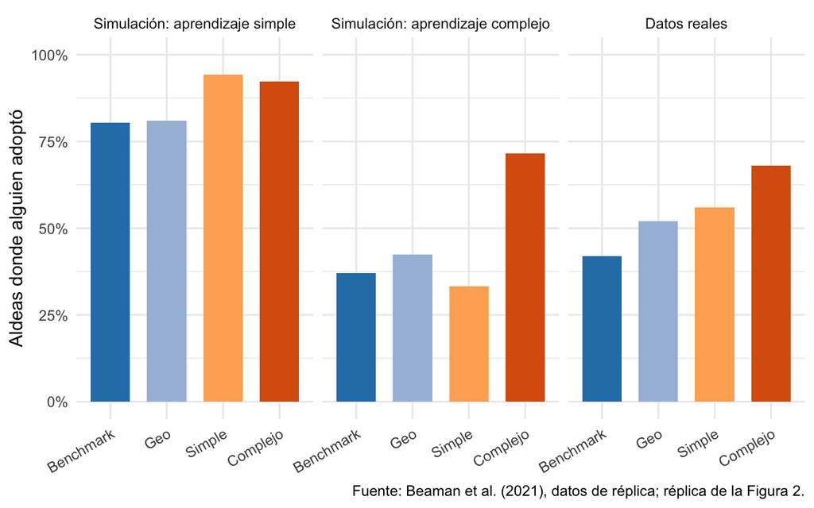

Figura 5: Aldeas donde alguien adoptó en el año 2: lo que predice cada modelo y lo observado.

```r
comparacion_sim |>
  pivot_longer(-brazo, names_to = "fuente", values_to = "adopcion") |>
  mutate(fuente = factor(fuente, levels = c("Simulación: aprendizaje simple",
                                            "Simulación: aprendizaje complejo",
                                            "Datos reales"))) |>
  ggplot(aes(brazo, adopcion, fill = brazo)) +
  geom_col(width = 0.7) +
  facet_wrap(~ fuente) +
  scale_fill_manual(values = colores_brazo, guide = "none") +
  scale_y_continuous(labels = label_percent(), limits = c(0, 1)) +
  labs(x = NULL, y = "Aldeas donde alguien adoptó",
       caption = "Fuente: Beaman et al. (2021), datos de réplica; réplica de la Figura 2.") +
  theme_minimal(base_size = 13) +
  theme(axis.text.x = element_text(angle = 30, hjust = 1))
```

Compare los tres paneles y verá el argumento completo.

Si bastara **un** vecino para convencerse, la difusión habría arrancado en más del **80 %** de las aldeas *sin importar a quién se capacitara*. El targeting sería irrelevante y la teoría de redes, un lujo académico. La realidad está muy por debajo de eso.

El modelo de **aprendizaje complejo** predice niveles parecidos a los observados y, sobre todo, **reproduce el patrón entre brazos**: el brazo Complejo arriba, el resto abajo. El panel del medio y el de la derecha se parecen; el de la izquierda no se parece a nada.

> **Por eso el targeting importa.** Cuando hace falta ver a *dos* vecinos adoptar, la información se muere si no entra por una parte densa de la red. Elegir bien a dos personas cambia el destino de una aldea entera.

## 10 Simple contra complejo

El titular del paper es **«el contagio complejo le gana al Benchmark»**. La pregunta interesante es otra: ¿le ganó el contagio complejo al **simple**? Para eso no sirve mirar si cada coeficiente es significativo por separado —ese es uno de los errores más comunes al leer una tabla de regresión—; hay que probar la **diferencia**.

Y la varianza de una diferencia no es la suma de las varianzas: hay que restarle dos veces la covarianza. Por eso vamos a la matriz de varianzas del modelo.

```r
prueba_igualdad <- function(modelo, a, b) {
  V  <- vcov(modelo)
  # Con errores agrupados, los grados de libertad son el número de clústeres
  # menos 1 (acá 199). Usar la t y no la normal cambia el tercer decimal —y es
  # justo lo que hace falta para que dé el número publicado.
  gl <- degrees_freedom(modelo, "t")
  diferencia <- coef(modelo)[[a]] - coef(modelo)[[b]]
  ee <- sqrt(V[a, a] + V[b, b] - 2 * V[a, b])
  tibble(comparacion = paste(a, "=", b),
         diferencia  = diferencia,
         ee          = ee,
         p           = 2 * pt(-abs(diferencia / ee), df = gl))
}

bind_rows(
  prueba_igualdad(m_a2_alguna, "simple",  "complex"),
  prueba_igualdad(m_a2_alguna, "complex", "geo"),
  prueba_igualdad(m_a2_alguna, "simple",  "geo")
)
```

| comparacion | diferencia | ee | p |
| --- | --- | --- | --- |
| simple = complex | -0.0976223 | 0.0938604 | 0.2995648 |
| complex = geo | 0.1456796 | 0.0886028 | 0.1017164 |
| simple = geo | 0.0480573 | 0.0974977 | 0.6226219 |

Lea esto con cuidado, porque es lo que separa una lectura ingenua de una lectura profesional. **No se puede rechazar que los tres algoritmos den lo mismo.** Lo que el experimento muestra con firmeza es que **alguna** regla de selección le gana a dejar que el extensionista elija a dedo. Cuál de las tres es la mejor, estos datos no lo resuelven: 50 aldeas por brazo no alcanzan para distinguir 0,252 de 0,155.

Que el paper se titule por el contagio complejo es una decisión de énfasis defendible —es el coeficiente más grande y es el que la teoría predecía antes de ver los datos— pero el lector tiene que ver la prueba de igualdad para calibrar cuánto creerle. Igual que en el Lab 2, donde el coeficiente titular de Dell no era significativo: **el paper lo dice, y hay que leerlo.**

## 11 Síntesis y discusión

- Elegir a los dos capacitados con el algoritmo de **contagio complejo** sube cerca de **25 puntos porcentuales** la probabilidad de que la difusión arranque, sobre una base de 42 % (Sección 7). Mismo programa, mismo presupuesto, otra lista de invitados.
- El resultado **no depende de los controles** y sobrevive a la inferencia por aleatorización (Sección 8): el sorteo es el que está haciendo el trabajo, no la especificación.
- El canal es **hablar**, y es delgado: capacitar a alguien sube unos 5 puntos la probabilidad de que un vecino haya hablado con él del tema (Sección 9).
- El targeting importa porque la difusión se parece al **contagio complejo** (Sección 9): si bastara un vecino para convencerse, la difusión habría arrancado en más del 80 % de las aldeas sin importar a quién se capacitara.
- Pero **no se puede rechazar que los tres algoritmos den lo mismo** (Sección 10). La lección robusta es «targetear con algún criterio de red le gana al criterio del extensionista», no «el contagio complejo es el mejor algoritmo».

**NotaPara discutir en clase**

1. ¿Por qué acá **no** tuvimos que defender ningún supuesto de identificación, y en el Lab 2 sí? Enuncie con sus palabras qué es exactamente lo que compra la aleatorización. Y diga una cosa que **no** compra.
2. En Sección 6, la diferencia cruda de medias y el coeficiente de Sección 7 no son idénticos. ¿Por qué? ¿Cuál de los dos reportaría usted, y qué tendría que pasar para que la diferencia entre ambos lo preocupara?
3. Suponga que es asesor del Ministerio de Agricultura. Medir la red social completa de una aldea —quién habla con quién, casa por casa— es caro. Con lo que muestra Sección 10, ¿recomendaría pagar por medir redes, o le bastaría otra regla? ¿Qué dato le haría falta para decidir?
4. En Sección 5, dos de doce variables salen desbalanceadas al 10 %. ¿Eso invalida el experimento? ¿Cuántas esperaría usted que salieran por puro azar? ¿Y qué tendría que ser cierto de esas dos para que sí lo preocuparan?
5. El efecto sobre la **tasa** de adopción es de 3,6 puntos sobre una base de 3,8 % (Sección 7). ¿Es esto un éxito? Compare con el argumento del capítulo de Todaro y Smith sobre por qué la transformación agrícola es lenta, y con lo que Pachón (2021) describe para el campo colombiano.

*Datos: paquete de réplica de Beaman, L., BenYishay, A., Magruder, J. y Mobarak, A. M. (2021), “Can Network Theory-Based Targeting Increase Technology Adoption?”, American Economic Review 111(6), 1918–1943. Depósito openICPSR-130605, licencia [CC BY 4.0](https://creativecommons.org/licenses/by/4.0). Ver `datos/SOURCE.md`.*